# 데이터 과학 – 금융(Finance)

## 3.2 ARIMA 모형 적합

모형 예측을 위해서 `tk_ts()` 함수로 `ts` 객체로 변환시키고 `auto.arima()` 함수로 최적 예측모형을 생성히킨다. `sw_glance()` 함수로 모형성능을 일별하고 나서 잔차검증을 통해 모형적합성을 검증한다.

```r
# 2. 시계열 예측 모형 -----
## 2.1. 티블을 ts로 변환
sunsplot_ts <- tk_ts(sunspots_train_df, start = 1749, freq = 12)

has_timetk_idx(sunsplot_ts) # sw_sweep()을 사용할 때 매우 중요한 요소.....
```

```
[1] TRUE
```

```r
## 2.2. 예측모형 적합: ARIMA, TBATS
sunspot_arima_fit <- auto.arima(sunsplot_ts)
# sunspot_tbats_fit <- tbats(sunsplot_ts)

## 2.3. 예측모형 성능평가
sw_glance(sunspot_arima_fit) %>%
  glimpse()
```

```
Observations: 1
Variables: 12
$ model.desc <chr> "ARIMA(2,1,2)"
$ sigma      <dbl> 15.70533
$ logLik     <dbl> -13163.96
$ AIC        <dbl> 26337.91
$ BIC        <dbl> 26368.2
$ ME         <dbl> 0.02253062
$ RMSE       <dbl> 15.69289
$ MAE        <dbl> 11.10848
$ MPE        <dbl> NaN
$ MAPE       <dbl> Inf
$ MASE       <dbl> 0.4726194
$ ACF1       <dbl> -0.006713671
```

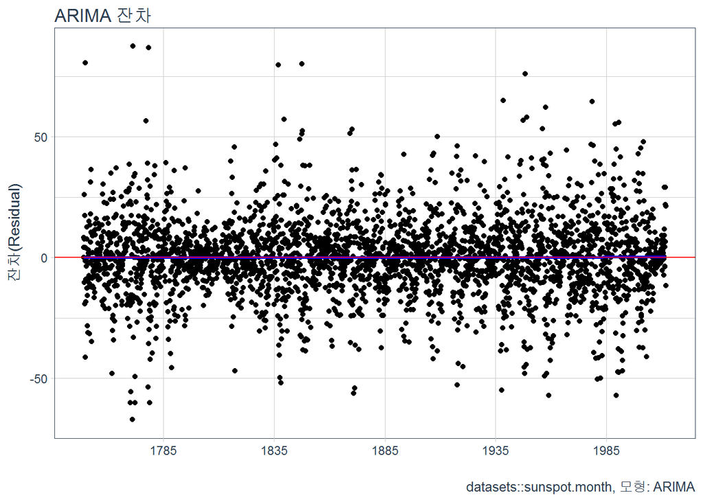

```r
## 2.4. 예측모형 검증 - 잔차
sw_augment(sunspot_arima_fit, timetk_idx = TRUE) %>%
  ggplot(aes(x = index, y = .resid)) +
  geom_point() +
  geom_smooth(method="loess", color="blue", size=1, se=FALSE) +
  geom_hline(yintercept = 0, color = "red") +
  scale_x_date(date_breaks = "50 year", date_labels = "%Y") +
  theme_tq(base_family = "NanumGothic") +
  labs(title = "ARIMA 잔차",
       x="", y="잔차(Residual)",
       caption = "datasets::sunspot.month, 모형: ARIMA")
```

## 3.3 ARIMA 모형 적합

`forecast()` 함수를 사용해서 태양흑점수를 예측한다. 예측값을 `sw_sweep()` 함수를 사용해서 원본데이터, 예측흑점수, 신뢰구간도 함께 하나의 데이터프레임으로 저장시켜서 후속 분석작업에 활용한다.

```r
## 2.5. 태양 흑점수 예측
sunspot_fcst_df <- forecast(sunspot_arima_fit, h = 21) %>%
  sw_sweep(., timetk_idx = TRUE)

sunspot_fcst_df %>%
  arrange(desc(index)) %>%
    DT::datatable() %>%
    DT::formatRound(c(3:7), digits = 0)
```

|  | index | key | value | lo.80 | lo.95 | hi.80 | hi.95 |
| --- | --- | --- | --- | --- | --- | --- | --- |
| 1 | 2013-09-01 | forecast | 111.948954500167 | 57.5779680972348 | 28.7957065008336 | 166.3199409031 | 195.102202499501 |
| 2 | 2013-08-01 | forecast | 111.230289710069 | 58.6977527519355 | 30.8887075040446 | 163.762826668202 | 191.571871916093 |
| 3 | 2013-07-01 | forecast | 110.445705911089 | 59.7634320384831 | 32.9338569027427 | 161.127979783695 | 187.957554919435 |
| 4 | 2013-06-01 | forecast | 109.589156794406 | 60.7660116284767 | 34.9205997812298 | 158.412301960335 | 184.257713807582 |
| 5 | 2013-05-01 | forecast | 108.65404155469 | 61.6952594477532 | 36.8367817877384 | 155.612823661627 | 180.471301321642 |
| 6 | 2013-04-01 | forecast | 107.633154165886 | 62.5395250306529 | 38.6683997124005 | 152.72678330112 | 176.597908619372 |
| 7 | 2013-03-01 | forecast | 106.518628196334 | 63.2855329023221 | 40.39931470586 | 149.751723490345 | 172.637941686808 |
| 8 | 2013-02-01 | forecast | 105.301877023846 | 63.9181494551446 | 42.0109273957649 | 146.685604592547 | 168.592826651926 |
| 9 | 2013-01-01 | forecast | 103.973529677717 | 64.4201266150339 | 43.4818198213823 | 143.526932740401 | 164.465239534053 |
| 10 | 2012-12-01 | forecast | 102.523363467311 | 64.7718339360394 | 44.7873813719286 | 140.274892998582 | 160.259345562693 |

[output cut: 3167 more lines]

## 3.4 ARIMA 모형 적합

태양흑점수를 `ggplot`으로 시각화하여 마무리한다.

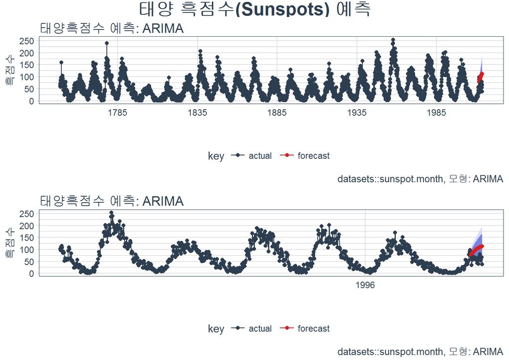

```r
# 3. 모형결과 정리 -----
## 3.1. 전체기간 -----
sunsplot_full_p <- sunspot_fcst_df %>%
  ggplot(aes(x = index, y = value, color = key)) +
  # 95% 신뢰구간
  geom_ribbon(aes(ymin = lo.95, ymax = hi.95),
              fill = "#D5DBFF", color = NA, size = 0) +
  # 80% 신뢰구간
  geom_ribbon(aes(ymin = lo.80, ymax = hi.80, fill = key),
              fill = "#596DD5", color = NA, size = 0, alpha = 0.8) +
  # 태양 흑점수 예측값
  geom_line() +
  geom_point() +
  # 실제 태양 흑점수
  geom_line(aes(x = date, y = value), color = palette_light()[[1]], data = sunspots_test_df) +
  geom_point(aes(x = date, y = value), color = palette_light()[[1]], data = sunspots_test_df) +
  theme_tq(base_family = "NanumGothic") +
  labs(title = "태양흑점수 예측: ARIMA",
       x="", y="흑점수",
       caption = "datasets::sunspot.month, 모형: ARIMA") +
  scale_x_date(date_breaks = "50 year", date_labels = "%Y") +
  scale_color_tq() +
  scale_fill_tq()

## 3.2. 최근(1950년 이후) -----
sunsplot_recent_p <- sunspot_fcst_df %>%
  filter(index >= "1950-01-01") %>%
  ggplot(aes(x = index, y = value, color = key)) +
  # 95% 신뢰구간
  geom_ribbon(aes(ymin = lo.95, ymax = hi.95),
              fill = "#D5DBFF", color = NA, size = 0) +
  # 80% 신뢰구간
  geom_ribbon(aes(ymin = lo.80, ymax = hi.80, fill = key),
              fill = "#596DD5", color = NA, size = 0, alpha = 0.8) +
  # 태양 흑점수 예측값
  geom_line() +
  geom_point() +
  # 실제 태양 흑점수
  geom_line(aes(x = date, y = value), color = palette_light()[[1]], data = sunspots_test_df) +
  geom_point(aes(x = date, y = value), color = palette_light()[[1]], data = sunspots_test_df) +
  theme_tq(base_family = "NanumGothic") +
  labs(title = "태양흑점수 예측: ARIMA",
       x="", y="흑점수",
       caption = "datasets::sunspot.month, 모형: ARIMA") +
  scale_x_date(date_breaks = "50 year", date_labels = "%Y") +
  scale_color_tq() +
  scale_fill_tq()

## 3.3. 그래프 결합 -----
sunspot_fcst_title <- ggdraw() +
  draw_label("태양 흑점수(Sunspots) 예측", size = 18, fontface = "bold", colour = palette_light()[[1]], fontfamily="NanumGothic")

plot_grid(sunspot_fcst_title, sunsplot_full_p, sunsplot_recent_p, ncol = 1, rel_heights = c(0.1, 1, 1))
```

[^1]: [Matt Dancho(April 18, 2018), “TIME SERIES DEEP LEARNING: FORECASTING SUNSPOTS WITH KERAS STATEFUL LSTM IN R”](http://www.business-science.io/timeseries-analysis/2018/04/18/keras-lstm-sunspots-time-series-prediction.html)
[^2]: [Time Series Deep Learning, S&P Global’s headquarters on April 19th, 2018.](https://github.com/business-science/presentations/tree/master/2018_04_19_SP_Global_Time_Series_Deep_Learning)
[^3]: [Matt Dancho(October 25, 2017), “DEMO WEEK: TIDY FORECASTING WITH SWEEP”](http://www.business-science.io/code-tools/2017/10/25/demo_week_sweep.html)